# Risk Factor Analysis

## Outcome Variable

**Outcome Variable:** pers_wast

## Predictor Variables

**Intervention Variable:** feducyrs

**Adjustment Set:**

- arm
- W_mage
- meducyrs
- W_mhtcm
- W_mwtkg
- W_mbmi
- W_gagebrth
- W_birthwt
- W_birthlen
- single
- delta_W_mage
- delta_meducyrs
- delta_W_mhtcm
- delta_W_mwtkg
- delta_W_mbmi
- delta_W_gagebrth
- delta_W_birthwt
- delta_W_birthlen
- delta_single

## Stratifying Variables

The analysis was stratified on these variable(s):

- agecat
- studyid
- country

## Data Summary

| agecat | studyid | country | feducyrs | pers_wast | n_cell | n |
| --- | --- | --- | --- | --- | --- | --- |
| 0-24 months | ki0047075b-MAL-ED | BANGLADESH | High | 0 | 48 | 138 |
| 0-24 months | ki0047075b-MAL-ED | BANGLADESH | High | 1 | 3 | 138 |
| 0-24 months | ki0047075b-MAL-ED | BANGLADESH | Low | 0 | 38 | 138 |
| 0-24 months | ki0047075b-MAL-ED | BANGLADESH | Low | 1 | 0 | 138 |
| 0-24 months | ki0047075b-MAL-ED | BANGLADESH | Medium | 0 | 45 | 138 |
| 0-24 months | ki0047075b-MAL-ED | BANGLADESH | Medium | 1 | 4 | 138 |
| 0-24 months | ki0047075b-MAL-ED | INDIA | High | 0 | 43 | 139 |
| 0-24 months | ki0047075b-MAL-ED | INDIA | High | 1 | 0 | 139 |
| 0-24 months | ki0047075b-MAL-ED | INDIA | Low | 0 | 51 | 139 |
| 0-24 months | ki0047075b-MAL-ED | INDIA | Low | 1 | 4 | 139 |
| 0-24 months | ki0047075b-MAL-ED | INDIA | Medium | 0 | 32 | 139 |
| 0-24 months | ki0047075b-MAL-ED | INDIA | Medium | 1 | 9 | 139 |
| 0-24 months | ki0047075b-MAL-ED | NEPAL | High | 0 | 40 | 96 |
| 0-24 months | ki0047075b-MAL-ED | NEPAL | High | 1 | 1 | 96 |
| 0-24 months | ki0047075b-MAL-ED | NEPAL | Low | 0 | 27 | 96 |
| 0-24 months | ki0047075b-MAL-ED | NEPAL | Low | 1 | 0 | 96 |
| 0-24 months | ki0047075b-MAL-ED | NEPAL | Medium | 0 | 27 | 96 |
| 0-24 months | ki0047075b-MAL-ED | NEPAL | Medium | 1 | 1 | 96 |
| 0-24 months | ki0047075b-MAL-ED | PERU | High | 0 | 110 | 234 |
| 0-24 months | ki0047075b-MAL-ED | PERU | High | 1 | 1 | 234 |
| 0-24 months | ki0047075b-MAL-ED | PERU | Low | 0 | 63 | 234 |
| 0-24 months | ki0047075b-MAL-ED | PERU | Low | 1 | 0 | 234 |
| 0-24 months | ki0047075b-MAL-ED | PERU | Medium | 0 | 60 | 234 |
| 0-24 months | ki0047075b-MAL-ED | PERU | Medium | 1 | 0 | 234 |
| 0-24 months | ki0047075b-MAL-ED | SOUTH AFRICA | High | 0 | 38 | 99 |
| 0-24 months | ki0047075b-MAL-ED | SOUTH AFRICA | High | 1 | 0 | 99 |
| 0-24 months | ki0047075b-MAL-ED | SOUTH AFRICA | Low | 0 | 35 | 99 |
| 0-24 months | ki0047075b-MAL-ED | SOUTH AFRICA | Low | 1 | 1 | 99 |
| 0-24 months | ki0047075b-MAL-ED | SOUTH AFRICA | Medium | 0 | 25 | 99 |
| 0-24 months | ki0047075b-MAL-ED | SOUTH AFRICA | Medium | 1 | 0 | 99 |

[output cut: 294 more lines]

The following strata were considered:

- agecat: 0-24 months, studyid: ki0047075b-MAL-ED, country: BANGLADESH
- agecat: 0-24 months, studyid: ki0047075b-MAL-ED, country: INDIA
- agecat: 0-24 months, studyid: ki0047075b-MAL-ED, country: NEPAL
- agecat: 0-24 months, studyid: ki0047075b-MAL-ED, country: PERU
- agecat: 0-24 months, studyid: ki0047075b-MAL-ED, country: SOUTH AFRICA
- agecat: 0-24 months, studyid: ki0047075b-MAL-ED, country: TANZANIA, UNITED REPUBLIC OF
- agecat: 0-24 months, studyid: ki1000304b-SAS-CompFeed, country: INDIA
- agecat: 0-24 months, studyid: ki1000304b-SAS-FoodSuppl, country: INDIA
- agecat: 0-24 months, studyid: ki1017093b-PROVIDE, country: BANGLADESH
- agecat: 0-24 months, studyid: ki1017093c-NIH-Crypto, country: BANGLADESH
- agecat: 0-24 months, studyid: ki1066203-TanzaniaChild2, country: TANZANIA, UNITED REPUBLIC OF
- agecat: 0-24 months, studyid: ki1113344-GMS-Nepal, country: NEPAL
- agecat: 0-24 months, studyid: ki1119695-PROBIT, country: BELARUS
- agecat: 0-24 months, studyid: ki1126311-ZVITAMBO, country: ZIMBABWE
- agecat: 0-24 months, studyid: ki1135781-COHORTS, country: GUATEMALA
- agecat: 0-24 months, studyid: ki1135781-COHORTS, country: INDIA
- agecat: 0-24 months, studyid: ki1135781-COHORTS, country: PHILIPPINES
- agecat: 0-24 months, studyid: ki1148112-LCNI-5, country: MALAWI
- agecat: 0-24 months, studyid: kiGH5241-JiVitA-3, country: BANGLADESH
- agecat: 0-24 months, studyid: kiGH5241-JiVitA-4, country: BANGLADESH
- agecat: 0-6 months, studyid: ki0047075b-MAL-ED, country: BANGLADESH
- agecat: 0-6 months, studyid: ki0047075b-MAL-ED, country: INDIA
- agecat: 0-6 months, studyid: ki0047075b-MAL-ED, country: NEPAL
- agecat: 0-6 months, studyid: ki0047075b-MAL-ED, country: PERU
- agecat: 0-6 months, studyid: ki0047075b-MAL-ED, country: SOUTH AFRICA
- agecat: 0-6 months, studyid: ki0047075b-MAL-ED, country: TANZANIA, UNITED REPUBLIC OF
- agecat: 0-6 months, studyid: ki1017093b-PROVIDE, country: BANGLADESH
- agecat: 0-6 months, studyid: ki1017093c-NIH-Crypto, country: BANGLADESH
- agecat: 0-6 months, studyid: ki1066203-TanzaniaChild2, country: TANZANIA, UNITED REPUBLIC OF
- agecat: 0-6 months, studyid: ki1113344-GMS-Nepal, country: NEPAL
- agecat: 0-6 months, studyid: ki1119695-PROBIT, country: BELARUS
- agecat: 0-6 months, studyid: ki1126311-ZVITAMBO, country: ZIMBABWE
- agecat: 0-6 months, studyid: ki1135781-COHORTS, country: PHILIPPINES
- agecat: 0-6 months, studyid: kiGH5241-JiVitA-3, country: BANGLADESH
- agecat: 6-24 months, studyid: ki0047075b-MAL-ED, country: BANGLADESH
- agecat: 6-24 months, studyid: ki0047075b-MAL-ED, country: INDIA
- agecat: 6-24 months, studyid: ki0047075b-MAL-ED, country: NEPAL
- agecat: 6-24 months, studyid: ki0047075b-MAL-ED, country: PERU
- agecat: 6-24 months, studyid: ki0047075b-MAL-ED, country: SOUTH AFRICA
- agecat: 6-24 months, studyid: ki0047075b-MAL-ED, country: TANZANIA, UNITED REPUBLIC OF
- agecat: 6-24 months, studyid: ki1000304b-SAS-CompFeed, country: INDIA
- agecat: 6-24 months, studyid: ki1000304b-SAS-FoodSuppl, country: INDIA
- agecat: 6-24 months, studyid: ki1017093b-PROVIDE, country: BANGLADESH
- agecat: 6-24 months, studyid: ki1017093c-NIH-Crypto, country: BANGLADESH
- agecat: 6-24 months, studyid: ki1066203-TanzaniaChild2, country: TANZANIA, UNITED REPUBLIC OF
- agecat: 6-24 months, studyid: ki1113344-GMS-Nepal, country: NEPAL
- agecat: 6-24 months, studyid: ki1119695-PROBIT, country: BELARUS
- agecat: 6-24 months, studyid: ki1126311-ZVITAMBO, country: ZIMBABWE
- agecat: 6-24 months, studyid: ki1135781-COHORTS, country: GUATEMALA
- agecat: 6-24 months, studyid: ki1135781-COHORTS, country: INDIA
- agecat: 6-24 months, studyid: ki1135781-COHORTS, country: PHILIPPINES
- agecat: 6-24 months, studyid: ki1148112-LCNI-5, country: MALAWI
- agecat: 6-24 months, studyid: kiGH5241-JiVitA-3, country: BANGLADESH
- agecat: 6-24 months, studyid: kiGH5241-JiVitA-4, country: BANGLADESH

### Dropped Strata

Some strata were dropped due to rare outcomes:

- agecat: 0-24 months, studyid: ki0047075b-MAL-ED, country: BANGLADESH
- agecat: 0-24 months, studyid: ki0047075b-MAL-ED, country: INDIA
- agecat: 0-24 months, studyid: ki0047075b-MAL-ED, country: NEPAL
- agecat: 0-24 months, studyid: ki0047075b-MAL-ED, country: PERU
- agecat: 0-24 months, studyid: ki0047075b-MAL-ED, country: SOUTH AFRICA
- agecat: 0-24 months, studyid: ki0047075b-MAL-ED, country: TANZANIA, UNITED REPUBLIC OF
- agecat: 0-24 months, studyid: ki1017093b-PROVIDE, country: BANGLADESH
- agecat: 0-24 months, studyid: ki1017093c-NIH-Crypto, country: BANGLADESH
- agecat: 0-24 months, studyid: ki1148112-LCNI-5, country: MALAWI
- agecat: 0-6 months, studyid: ki0047075b-MAL-ED, country: BANGLADESH
- agecat: 0-6 months, studyid: ki0047075b-MAL-ED, country: INDIA
- agecat: 0-6 months, studyid: ki0047075b-MAL-ED, country: NEPAL
- agecat: 0-6 months, studyid: ki0047075b-MAL-ED, country: PERU
- agecat: 0-6 months, studyid: ki0047075b-MAL-ED, country: SOUTH AFRICA
- agecat: 0-6 months, studyid: ki0047075b-MAL-ED, country: TANZANIA, UNITED REPUBLIC OF
- agecat: 0-6 months, studyid: ki1017093b-PROVIDE, country: BANGLADESH
- agecat: 0-6 months, studyid: ki1017093c-NIH-Crypto, country: BANGLADESH
- agecat: 0-6 months, studyid: ki1126311-ZVITAMBO, country: ZIMBABWE
- agecat: 0-6 months, studyid: kiGH5241-JiVitA-3, country: BANGLADESH
- agecat: 6-24 months, studyid: ki0047075b-MAL-ED, country: BANGLADESH
- agecat: 6-24 months, studyid: ki0047075b-MAL-ED, country: INDIA
- agecat: 6-24 months, studyid: ki0047075b-MAL-ED, country: NEPAL
- agecat: 6-24 months, studyid: ki0047075b-MAL-ED, country: PERU
- agecat: 6-24 months, studyid: ki0047075b-MAL-ED, country: SOUTH AFRICA
- agecat: 6-24 months, studyid: ki0047075b-MAL-ED, country: TANZANIA, UNITED REPUBLIC OF
- agecat: 6-24 months, studyid: ki1017093b-PROVIDE, country: BANGLADESH
- agecat: 6-24 months, studyid: ki1017093c-NIH-Crypto, country: BANGLADESH
- agecat: 6-24 months, studyid: ki1148112-LCNI-5, country: MALAWI

## Methods Detail

We’re interested in the causal parameters $E[Y_a]$ for all values of $a \in \mathcal{A}$. These parameters represent the mean outcome if, possibly contrary to fact, we intervened to set all units to have $A=a$. Under the randomization and positivity assumptions, these are identified by the statistical parameters $\psi_a=E_W[E_{Y|A,W}(Y|A=a,W)]$. In addition, we’re interested in the mean of $Y$, $E[Y]$ under no intervention (the observed mean). We will estimate these parameters by using SuperLearner to fit the relevant likelihood factors – $E_{Y|A,W}(Y|A=a,W)$ and $p(A=a|W)$, and then updating our likelihood fit using a joint TMLE.

For unadjusted analyses ($W=\{\}$), initial likelihoods were estimated using Lrnr_glm to estimate the simple $E(Y|A)$ and Lrnr_mean to estimate $p(A)$. For adjusted analyses, a small library containing Lrnr_glmnet, Lrnr_xgboost, and Lrnr_mean was used.

Having estimated these parameters, we will then use the delta method to estimate relative risks and attributable risks relative to a prespecified baseline level of $A$.

# Results Detail

## Results Plots

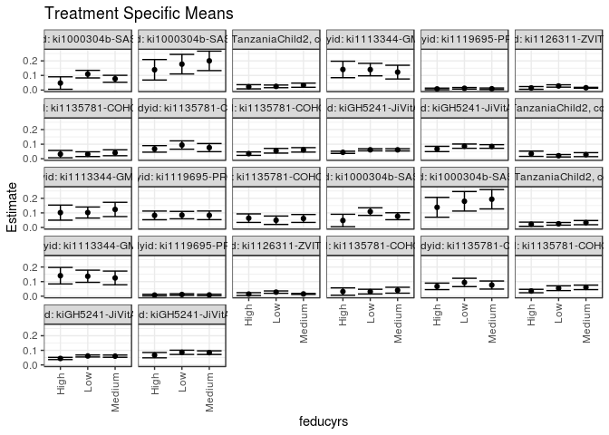

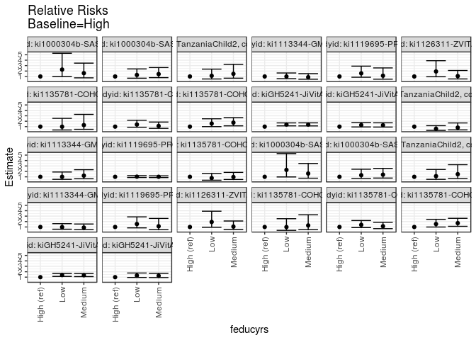

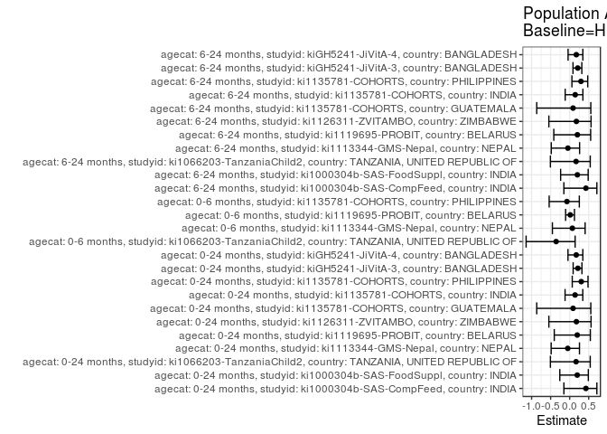

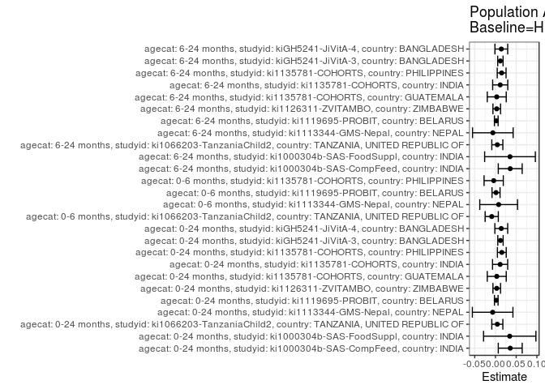

## Results Table

### Parameter: TSM

| agecat | studyid | country | intervention_level | baseline_level | estimate | ci_lower | ci_upper |
| --- | --- | --- | --- | --- | --- | --- | --- |
| 0-24 months | ki1000304b-SAS-CompFeed | INDIA | High | NA | 0.0479762 | 0.0053159 | 0.0906364 |
| 0-24 months | ki1000304b-SAS-CompFeed | INDIA | Low | NA | 0.1089371 | 0.0829270 | 0.1349472 |
| 0-24 months | ki1000304b-SAS-CompFeed | INDIA | Medium | NA | 0.0770914 | 0.0531683 | 0.1010145 |
| 0-24 months | ki1000304b-SAS-FoodSuppl | INDIA | High | NA | 0.1388870 | 0.0686615 | 0.2091125 |
| 0-24 months | ki1000304b-SAS-FoodSuppl | INDIA | Low | NA | 0.1773155 | 0.1102394 | 0.2443916 |
| 0-24 months | ki1000304b-SAS-FoodSuppl | INDIA | Medium | NA | 0.1999375 | 0.1333037 | 0.2665714 |
| 0-24 months | ki1066203-TanzaniaChild2 | TANZANIA, UNITED REPUBLIC OF | High | NA | 0.0223881 | 0.0079228 | 0.0368534 |
| 0-24 months | ki1066203-TanzaniaChild2 | TANZANIA, UNITED REPUBLIC OF | Low | NA | 0.0251736 | 0.0161255 | 0.0342217 |
| 0-24 months | ki1066203-TanzaniaChild2 | TANZANIA, UNITED REPUBLIC OF | Medium | NA | 0.0332779 | 0.0189349 | 0.0476209 |
| 0-24 months | ki1113344-GMS-Nepal | NEPAL | High | NA | 0.1409893 | 0.0845282 | 0.1974505 |
| 0-24 months | ki1113344-GMS-Nepal | NEPAL | Low | NA | 0.1400728 | 0.0973731 | 0.1827726 |
| 0-24 months | ki1113344-GMS-Nepal | NEPAL | Medium | NA | 0.1226910 | 0.0755432 | 0.1698388 |
| 0-24 months | ki1119695-PROBIT | BELARUS | High | NA | 0.0076069 | 0.0022063 | 0.0130074 |
| 0-24 months | ki1119695-PROBIT | BELARUS | Low | NA | 0.0120236 | 0.0067487 | 0.0172985 |
| 0-24 months | ki1119695-PROBIT | BELARUS | Medium | NA | 0.0086585 | 0.0033988 | 0.0139183 |
| 0-24 months | ki1126311-ZVITAMBO | ZIMBABWE | High | NA | 0.0145161 | 0.0051010 | 0.0239312 |
| 0-24 months | ki1126311-ZVITAMBO | ZIMBABWE | Low | NA | 0.0278983 | 0.0198612 | 0.0359354 |
| 0-24 months | ki1126311-ZVITAMBO | ZIMBABWE | Medium | NA | 0.0155426 | 0.0126474 | 0.0184378 |
| 0-24 months | ki1135781-COHORTS | GUATEMALA | High | NA | 0.0319149 | 0.0067764 | 0.0570534 |
| 0-24 months | ki1135781-COHORTS | GUATEMALA | Low | NA | 0.0314607 | 0.0152340 | 0.0476873 |
| 0-24 months | ki1135781-COHORTS | GUATEMALA | Medium | NA | 0.0409836 | 0.0206627 | 0.0613045 |
| 0-24 months | ki1135781-COHORTS | INDIA | High | NA | 0.0676598 | 0.0453439 | 0.0899757 |
| 0-24 months | ki1135781-COHORTS | INDIA | Low | NA | 0.0941235 | 0.0655315 | 0.1227155 |
| 0-24 months | ki1135781-COHORTS | INDIA | Medium | NA | 0.0763498 | 0.0484939 | 0.1042057 |
| 0-24 months | ki1135781-COHORTS | PHILIPPINES | High | NA | 0.0350234 | 0.0232510 | 0.0467958 |
| 0-24 months | ki1135781-COHORTS | PHILIPPINES | Low | NA | 0.0548891 | 0.0388012 | 0.0709770 |
| 0-24 months | ki1135781-COHORTS | PHILIPPINES | Medium | NA | 0.0610480 | 0.0457216 | 0.0763743 |
| 0-24 months | kiGH5241-JiVitA-3 | BANGLADESH | High | NA | 0.0441253 | 0.0366404 | 0.0516101 |
| 0-24 months | kiGH5241-JiVitA-3 | BANGLADESH | Low | NA | 0.0613126 | 0.0544217 | 0.0682035 |
| 0-24 months | kiGH5241-JiVitA-3 | BANGLADESH | Medium | NA | 0.0611996 | 0.0536877 | 0.0687116 |
| 0-24 months | kiGH5241-JiVitA-4 | BANGLADESH | High | NA | 0.0670477 | 0.0488571 | 0.0852383 |
| 0-24 months | kiGH5241-JiVitA-4 | BANGLADESH | Low | NA | 0.0863415 | 0.0717913 | 0.1008917 |
| 0-24 months | kiGH5241-JiVitA-4 | BANGLADESH | Medium | NA | 0.0841900 | 0.0718057 | 0.0965744 |
| 0-6 months | ki1066203-TanzaniaChild2 | TANZANIA, UNITED REPUBLIC OF | High | NA | 0.0343595 | 0.0162215 | 0.0524975 |
| 0-6 months | ki1066203-TanzaniaChild2 | TANZANIA, UNITED REPUBLIC OF | Low | NA | 0.0207299 | 0.0123106 | 0.0291491 |
| 0-6 months | ki1066203-TanzaniaChild2 | TANZANIA, UNITED REPUBLIC OF | Medium | NA | 0.0282167 | 0.0145008 | 0.0419326 |
| 0-6 months | ki1113344-GMS-Nepal | NEPAL | High | NA | 0.1017998 | 0.0502030 | 0.1533966 |
| 0-6 months | ki1113344-GMS-Nepal | NEPAL | Low | NA | 0.1023642 | 0.0646055 | 0.1401229 |
| 0-6 months | ki1113344-GMS-Nepal | NEPAL | Medium | NA | 0.1236601 | 0.0748131 | 0.1725072 |
| 0-6 months | ki1119695-PROBIT | BELARUS | High | NA | 0.0828035 | 0.0530627 | 0.1125443 |
| 0-6 months | ki1119695-PROBIT | BELARUS | Low | NA | 0.0849606 | 0.0594312 | 0.1104900 |
| 0-6 months | ki1119695-PROBIT | BELARUS | Medium | NA | 0.0833385 | 0.0538081 | 0.1128689 |
| 0-6 months | ki1135781-COHORTS | PHILIPPINES | High | NA | 0.0639756 | 0.0347655 | 0.0931857 |
| 0-6 months | ki1135781-COHORTS | PHILIPPINES | Low | NA | 0.0495485 | 0.0207372 | 0.0783598 |
| 0-6 months | ki1135781-COHORTS | PHILIPPINES | Medium | NA | 0.0617462 | 0.0346642 | 0.0888282 |
| 6-24 months | ki1000304b-SAS-CompFeed | INDIA | High | NA | 0.0479762 | 0.0053159 | 0.0906364 |
| 6-24 months | ki1000304b-SAS-CompFeed | INDIA | Low | NA | 0.1089371 | 0.0829270 | 0.1349472 |
| 6-24 months | ki1000304b-SAS-CompFeed | INDIA | Medium | NA | 0.0770914 | 0.0531683 | 0.1010145 |
| 6-24 months | ki1000304b-SAS-FoodSuppl | INDIA | High | NA | 0.1382303 | 0.0701366 | 0.2063240 |
| 6-24 months | ki1000304b-SAS-FoodSuppl | INDIA | Low | NA | 0.1795219 | 0.1126133 | 0.2464306 |
| 6-24 months | ki1000304b-SAS-FoodSuppl | INDIA | Medium | NA | 0.1935948 | 0.1271864 | 0.2600033 |
| 6-24 months | ki1066203-TanzaniaChild2 | TANZANIA, UNITED REPUBLIC OF | High | NA | 0.0223881 | 0.0079228 | 0.0368534 |
| 6-24 months | ki1066203-TanzaniaChild2 | TANZANIA, UNITED REPUBLIC OF | Low | NA | 0.0251736 | 0.0161255 | 0.0342217 |
| 6-24 months | ki1066203-TanzaniaChild2 | TANZANIA, UNITED REPUBLIC OF | Medium | NA | 0.0332779 | 0.0189349 | 0.0476209 |
| 6-24 months | ki1113344-GMS-Nepal | NEPAL | High | NA | 0.1405429 | 0.0840534 | 0.1970324 |
| 6-24 months | ki1113344-GMS-Nepal | NEPAL | Low | NA | 0.1367488 | 0.0949857 | 0.1785119 |
| 6-24 months | ki1113344-GMS-Nepal | NEPAL | Medium | NA | 0.1252399 | 0.0782977 | 0.1721822 |
| 6-24 months | ki1119695-PROBIT | BELARUS | High | NA | 0.0075709 | 0.0020924 | 0.0130494 |
| 6-24 months | ki1119695-PROBIT | BELARUS | Low | NA | 0.0117114 | 0.0064597 | 0.0169632 |
| 6-24 months | ki1119695-PROBIT | BELARUS | Medium | NA | 0.0085900 | 0.0034272 | 0.0137529 |
| 6-24 months | ki1126311-ZVITAMBO | ZIMBABWE | High | NA | 0.0145161 | 0.0051010 | 0.0239312 |
| 6-24 months | ki1126311-ZVITAMBO | ZIMBABWE | Low | NA | 0.0278983 | 0.0198612 | 0.0359354 |
| 6-24 months | ki1126311-ZVITAMBO | ZIMBABWE | Medium | NA | 0.0155426 | 0.0126474 | 0.0184378 |
| 6-24 months | ki1135781-COHORTS | GUATEMALA | High | NA | 0.0319149 | 0.0067764 | 0.0570534 |
| 6-24 months | ki1135781-COHORTS | GUATEMALA | Low | NA | 0.0314607 | 0.0152340 | 0.0476873 |
| 6-24 months | ki1135781-COHORTS | GUATEMALA | Medium | NA | 0.0409836 | 0.0206627 | 0.0613045 |
| 6-24 months | ki1135781-COHORTS | INDIA | High | NA | 0.0674046 | 0.0450976 | 0.0897116 |
| 6-24 months | ki1135781-COHORTS | INDIA | Low | NA | 0.0942677 | 0.0657460 | 0.1227893 |
| 6-24 months | ki1135781-COHORTS | INDIA | Medium | NA | 0.0764610 | 0.0487720 | 0.1041501 |
| 6-24 months | ki1135781-COHORTS | PHILIPPINES | High | NA | 0.0354459 | 0.0236449 | 0.0472470 |
| 6-24 months | ki1135781-COHORTS | PHILIPPINES | Low | NA | 0.0548415 | 0.0386764 | 0.0710065 |
| 6-24 months | ki1135781-COHORTS | PHILIPPINES | Medium | NA | 0.0606543 | 0.0453099 | 0.0759987 |
| 6-24 months | kiGH5241-JiVitA-3 | BANGLADESH | High | NA | 0.0443216 | 0.0368113 | 0.0518319 |
| 6-24 months | kiGH5241-JiVitA-3 | BANGLADESH | Low | NA | 0.0613468 | 0.0544199 | 0.0682736 |
| 6-24 months | kiGH5241-JiVitA-3 | BANGLADESH | Medium | NA | 0.0601908 | 0.0526189 | 0.0677627 |
| 6-24 months | kiGH5241-JiVitA-4 | BANGLADESH | High | NA | 0.0669391 | 0.0488331 | 0.0850452 |
| 6-24 months | kiGH5241-JiVitA-4 | BANGLADESH | Low | NA | 0.0863767 | 0.0717892 | 0.1009642 |
| 6-24 months | kiGH5241-JiVitA-4 | BANGLADESH | Medium | NA | 0.0840800 | 0.0716661 | 0.0964939 |

### Parameter: E(Y)

| agecat | studyid | country | intervention_level | baseline_level | estimate | ci_lower | ci_upper |
| --- | --- | --- | --- | --- | --- | --- | --- |
| 0-24 months | ki1000304b-SAS-CompFeed | INDIA | NA | NA | 0.0836390 | 0.0602327 | 0.1070453 |
| 0-24 months | ki1000304b-SAS-FoodSuppl | INDIA | NA | NA | 0.1733333 | 0.1349698 | 0.2116969 |
| 0-24 months | ki1066203-TanzaniaChild2 | TANZANIA, UNITED REPUBLIC OF | NA | NA | 0.0269142 | 0.0200799 | 0.0337484 |
| 0-24 months | ki1113344-GMS-Nepal | NEPAL | NA | NA | 0.1342282 | 0.1068369 | 0.1616195 |
| 0-24 months | ki1119695-PROBIT | BELARUS | NA | NA | 0.0094941 | 0.0051728 | 0.0138153 |
| 0-24 months | ki1126311-ZVITAMBO | ZIMBABWE | NA | NA | 0.0176292 | 0.0149467 | 0.0203118 |
| 0-24 months | ki1135781-COHORTS | GUATEMALA | NA | NA | 0.0350350 | 0.0236276 | 0.0464425 |
| 0-24 months | ki1135781-COHORTS | INDIA | NA | NA | 0.0789050 | 0.0639058 | 0.0939041 |
| 0-24 months | ki1135781-COHORTS | PHILIPPINES | NA | NA | 0.0503949 | 0.0420785 | 0.0587113 |
| 0-24 months | kiGH5241-JiVitA-3 | BANGLADESH | NA | NA | 0.0562249 | 0.0520204 | 0.0604294 |
| 0-24 months | kiGH5241-JiVitA-4 | BANGLADESH | NA | NA | 0.0810600 | 0.0722782 | 0.0898418 |
| 0-6 months | ki1066203-TanzaniaChild2 | TANZANIA, UNITED REPUBLIC OF | NA | NA | 0.0253535 | 0.0185487 | 0.0321583 |
| 0-6 months | ki1113344-GMS-Nepal | NEPAL | NA | NA | 0.1095406 | 0.0837882 | 0.1352931 |
| 0-6 months | ki1119695-PROBIT | BELARUS | NA | NA | 0.0841807 | 0.0567141 | 0.1116474 |
| 0-6 months | ki1135781-COHORTS | PHILIPPINES | NA | NA | 0.0597015 | 0.0433139 | 0.0760891 |
| 6-24 months | ki1000304b-SAS-CompFeed | INDIA | NA | NA | 0.0836390 | 0.0602327 | 0.1070453 |
| 6-24 months | ki1000304b-SAS-FoodSuppl | INDIA | NA | NA | 0.1733333 | 0.1349698 | 0.2116969 |
| 6-24 months | ki1066203-TanzaniaChild2 | TANZANIA, UNITED REPUBLIC OF | NA | NA | 0.0269142 | 0.0200799 | 0.0337484 |
| 6-24 months | ki1113344-GMS-Nepal | NEPAL | NA | NA | 0.1342282 | 0.1068369 | 0.1616195 |
| 6-24 months | ki1119695-PROBIT | BELARUS | NA | NA | 0.0094941 | 0.0051728 | 0.0138153 |
| 6-24 months | ki1126311-ZVITAMBO | ZIMBABWE | NA | NA | 0.0176292 | 0.0149467 | 0.0203118 |
| 6-24 months | ki1135781-COHORTS | GUATEMALA | NA | NA | 0.0350350 | 0.0236276 | 0.0464425 |
| 6-24 months | ki1135781-COHORTS | INDIA | NA | NA | 0.0789050 | 0.0639058 | 0.0939041 |
| 6-24 months | ki1135781-COHORTS | PHILIPPINES | NA | NA | 0.0503949 | 0.0420785 | 0.0587113 |
| 6-24 months | kiGH5241-JiVitA-3 | BANGLADESH | NA | NA | 0.0562249 | 0.0520204 | 0.0604294 |
| 6-24 months | kiGH5241-JiVitA-4 | BANGLADESH | NA | NA | 0.0810600 | 0.0722782 | 0.0898418 |

### Parameter: RR

| agecat | studyid | country | intervention_level | baseline_level | estimate | ci_lower | ci_upper |
| --- | --- | --- | --- | --- | --- | --- | --- |
| 0-24 months | ki1000304b-SAS-CompFeed | INDIA | High | High | 1.0000000 | 1.0000000 | 1.000000 |
| 0-24 months | ki1000304b-SAS-CompFeed | INDIA | Low | High | 2.2706501 | 0.9774568 | 5.274762 |
| 0-24 months | ki1000304b-SAS-CompFeed | INDIA | Medium | High | 1.6068688 | 0.7466768 | 3.458025 |
| 0-24 months | ki1000304b-SAS-FoodSuppl | INDIA | High | High | 1.0000000 | 1.0000000 | 1.000000 |
| 0-24 months | ki1000304b-SAS-FoodSuppl | INDIA | Low | High | 1.2766887 | 0.6814740 | 2.391777 |
| 0-24 months | ki1000304b-SAS-FoodSuppl | INDIA | Medium | High | 1.4395697 | 0.7846264 | 2.641207 |
| 0-24 months | ki1066203-TanzaniaChild2 | TANZANIA, UNITED REPUBLIC OF | High | High | 1.0000000 | 1.0000000 | 1.000000 |
| 0-24 months | ki1066203-TanzaniaChild2 | TANZANIA, UNITED REPUBLIC OF | Low | High | 1.1244213 | 0.5368195 | 2.355211 |
| 0-24 months | ki1066203-TanzaniaChild2 | TANZANIA, UNITED REPUBLIC OF | Medium | High | 1.4864115 | 0.6836450 | 3.231822 |
| 0-24 months | ki1113344-GMS-Nepal | NEPAL | High | High | 1.0000000 | 1.0000000 | 1.000000 |
| 0-24 months | ki1113344-GMS-Nepal | NEPAL | Low | High | 0.9934997 | 0.6009882 | 1.642364 |
| 0-24 months | ki1113344-GMS-Nepal | NEPAL | Medium | High | 0.8702149 | 0.4995336 | 1.515962 |
| 0-24 months | ki1119695-PROBIT | BELARUS | High | High | 1.0000000 | 1.0000000 | 1.000000 |
| 0-24 months | ki1119695-PROBIT | BELARUS | Low | High | 1.5806267 | 0.8600132 | 2.905049 |
| 0-24 months | ki1119695-PROBIT | BELARUS | Medium | High | 1.1382514 | 0.5036344 | 2.572533 |
| 0-24 months | ki1126311-ZVITAMBO | ZIMBABWE | High | High | 1.0000000 | 1.0000000 | 1.000000 |
| 0-24 months | ki1126311-ZVITAMBO | ZIMBABWE | Low | High | 1.9218847 | 0.9451687 | 3.907917 |
| 0-24 months | ki1126311-ZVITAMBO | ZIMBABWE | Medium | High | 1.0707100 | 0.5452590 | 2.102524 |
| 0-24 months | ki1135781-COHORTS | GUATEMALA | High | High | 1.0000000 | 1.0000000 | 1.000000 |
| 0-24 months | ki1135781-COHORTS | GUATEMALA | Low | High | 0.9857678 | 0.3844846 | 2.527379 |
| 0-24 months | ki1135781-COHORTS | GUATEMALA | Medium | High | 1.2841530 | 0.5062921 | 3.257110 |
| 0-24 months | ki1135781-COHORTS | INDIA | High | High | 1.0000000 | 1.0000000 | 1.000000 |
| 0-24 months | ki1135781-COHORTS | INDIA | Low | High | 1.3911299 | 0.8883320 | 2.178513 |
| 0-24 months | ki1135781-COHORTS | INDIA | Medium | High | 1.1284371 | 0.6901959 | 1.844940 |
| 0-24 months | ki1135781-COHORTS | PHILIPPINES | High | High | 1.0000000 | 1.0000000 | 1.000000 |
| 0-24 months | ki1135781-COHORTS | PHILIPPINES | Low | High | 1.5672138 | 1.0033559 | 2.447944 |
| 0-24 months | ki1135781-COHORTS | PHILIPPINES | Medium | High | 1.7430641 | 1.1457186 | 2.651849 |
| 0-24 months | kiGH5241-JiVitA-3 | BANGLADESH | High | High | 1.0000000 | 1.0000000 | 1.000000 |
| 0-24 months | kiGH5241-JiVitA-3 | BANGLADESH | Low | High | 1.3895125 | 1.1428788 | 1.689370 |
| 0-24 months | kiGH5241-JiVitA-3 | BANGLADESH | Medium | High | 1.3869522 | 1.1339196 | 1.696449 |
| 0-24 months | kiGH5241-JiVitA-4 | BANGLADESH | High | High | 1.0000000 | 1.0000000 | 1.000000 |
| 0-24 months | kiGH5241-JiVitA-4 | BANGLADESH | Low | High | 1.2877620 | 0.9424470 | 1.759601 |
| 0-24 months | kiGH5241-JiVitA-4 | BANGLADESH | Medium | High | 1.2556737 | 0.9240548 | 1.706302 |
| 0-6 months | ki1066203-TanzaniaChild2 | TANZANIA, UNITED REPUBLIC OF | High | High | 1.0000000 | 1.0000000 | 1.000000 |
| 0-6 months | ki1066203-TanzaniaChild2 | TANZANIA, UNITED REPUBLIC OF | Low | High | 0.6033232 | 0.3098838 | 1.174630 |
| 0-6 months | ki1066203-TanzaniaChild2 | TANZANIA, UNITED REPUBLIC OF | Medium | High | 0.8212190 | 0.4006235 | 1.683378 |
| 0-6 months | ki1113344-GMS-Nepal | NEPAL | High | High | 1.0000000 | 1.0000000 | 1.000000 |
| 0-6 months | ki1113344-GMS-Nepal | NEPAL | Low | High | 1.0055445 | 0.5369494 | 1.883082 |
| 0-6 months | ki1113344-GMS-Nepal | NEPAL | Medium | High | 1.2147387 | 0.6387343 | 2.310178 |
| 0-6 months | ki1119695-PROBIT | BELARUS | High | High | 1.0000000 | 1.0000000 | 1.000000 |
| 0-6 months | ki1119695-PROBIT | BELARUS | Low | High | 1.0260513 | 0.8690209 | 1.211457 |
| 0-6 months | ki1119695-PROBIT | BELARUS | Medium | High | 1.0064611 | 0.8579297 | 1.180707 |
| 0-6 months | ki1135781-COHORTS | PHILIPPINES | High | High | 1.0000000 | 1.0000000 | 1.000000 |
| 0-6 months | ki1135781-COHORTS | PHILIPPINES | Low | High | 0.7744905 | 0.3697931 | 1.622084 |
| 0-6 months | ki1135781-COHORTS | PHILIPPINES | Medium | High | 0.9651517 | 0.5122505 | 1.818481 |
| 6-24 months | ki1000304b-SAS-CompFeed | INDIA | High | High | 1.0000000 | 1.0000000 | 1.000000 |
| 6-24 months | ki1000304b-SAS-CompFeed | INDIA | Low | High | 2.2706501 | 0.9774568 | 5.274762 |
| 6-24 months | ki1000304b-SAS-CompFeed | INDIA | Medium | High | 1.6068688 | 0.7466768 | 3.458025 |
| 6-24 months | ki1000304b-SAS-FoodSuppl | INDIA | High | High | 1.0000000 | 1.0000000 | 1.000000 |
| 6-24 months | ki1000304b-SAS-FoodSuppl | INDIA | Low | High | 1.2987164 | 0.7018632 | 2.403124 |
| 6-24 months | ki1000304b-SAS-FoodSuppl | INDIA | Medium | High | 1.4005240 | 0.7683287 | 2.552901 |
| 6-24 months | ki1066203-TanzaniaChild2 | TANZANIA, UNITED REPUBLIC OF | High | High | 1.0000000 | 1.0000000 | 1.000000 |
| 6-24 months | ki1066203-TanzaniaChild2 | TANZANIA, UNITED REPUBLIC OF | Low | High | 1.1244213 | 0.5368195 | 2.355211 |
| 6-24 months | ki1066203-TanzaniaChild2 | TANZANIA, UNITED REPUBLIC OF | Medium | High | 1.4864115 | 0.6836450 | 3.231822 |
| 6-24 months | ki1113344-GMS-Nepal | NEPAL | High | High | 1.0000000 | 1.0000000 | 1.000000 |
| 6-24 months | ki1113344-GMS-Nepal | NEPAL | Low | High | 0.9730041 | 0.5880716 | 1.609901 |
| 6-24 months | ki1113344-GMS-Nepal | NEPAL | Medium | High | 0.8911154 | 0.5139954 | 1.544929 |
| 6-24 months | ki1119695-PROBIT | BELARUS | High | High | 1.0000000 | 1.0000000 | 1.000000 |
| 6-24 months | ki1119695-PROBIT | BELARUS | Low | High | 1.5468964 | 0.8359923 | 2.862333 |
| 6-24 months | ki1119695-PROBIT | BELARUS | Medium | High | 1.1346091 | 0.4990111 | 2.579778 |
| 6-24 months | ki1126311-ZVITAMBO | ZIMBABWE | High | High | 1.0000000 | 1.0000000 | 1.000000 |
| 6-24 months | ki1126311-ZVITAMBO | ZIMBABWE | Low | High | 1.9218847 | 0.9451687 | 3.907917 |
| 6-24 months | ki1126311-ZVITAMBO | ZIMBABWE | Medium | High | 1.0707100 | 0.5452590 | 2.102524 |
| 6-24 months | ki1135781-COHORTS | GUATEMALA | High | High | 1.0000000 | 1.0000000 | 1.000000 |
| 6-24 months | ki1135781-COHORTS | GUATEMALA | Low | High | 0.9857678 | 0.3844846 | 2.527379 |
| 6-24 months | ki1135781-COHORTS | GUATEMALA | Medium | High | 1.2841530 | 0.5062921 | 3.257110 |
| 6-24 months | ki1135781-COHORTS | INDIA | High | High | 1.0000000 | 1.0000000 | 1.000000 |
| 6-24 months | ki1135781-COHORTS | INDIA | Low | High | 1.3985344 | 0.8931791 | 2.189817 |
| 6-24 months | ki1135781-COHORTS | INDIA | Medium | High | 1.1343594 | 0.6947066 | 1.852251 |
| 6-24 months | ki1135781-COHORTS | PHILIPPINES | High | High | 1.0000000 | 1.0000000 | 1.000000 |
| 6-24 months | ki1135781-COHORTS | PHILIPPINES | Low | High | 1.5471860 | 0.9916916 | 2.413840 |
| 6-24 months | ki1135781-COHORTS | PHILIPPINES | Medium | High | 1.7111774 | 1.1261782 | 2.600058 |
| 6-24 months | kiGH5241-JiVitA-3 | BANGLADESH | High | High | 1.0000000 | 1.0000000 | 1.000000 |
| 6-24 months | kiGH5241-JiVitA-3 | BANGLADESH | Low | High | 1.3841280 | 1.1395656 | 1.681176 |
| 6-24 months | kiGH5241-JiVitA-3 | BANGLADESH | Medium | High | 1.3580465 | 1.1059957 | 1.667538 |
| 6-24 months | kiGH5241-JiVitA-4 | BANGLADESH | High | High | 1.0000000 | 1.0000000 | 1.000000 |
| 6-24 months | kiGH5241-JiVitA-4 | BANGLADESH | Low | High | 1.2903768 | 0.9449494 | 1.762076 |
| 6-24 months | kiGH5241-JiVitA-4 | BANGLADESH | Medium | High | 1.2560664 | 0.9246876 | 1.706201 |

### Parameter: PAR

| agecat | studyid | country | intervention_level | baseline_level | estimate | ci_lower | ci_upper |
| --- | --- | --- | --- | --- | --- | --- | --- |
| 0-24 months | ki1000304b-SAS-CompFeed | INDIA | High | NA | 0.0356629 | 0.0068211 | 0.0645046 |
| 0-24 months | ki1000304b-SAS-FoodSuppl | INDIA | High | NA | 0.0344463 | -0.0287252 | 0.0976179 |
| 0-24 months | ki1066203-TanzaniaChild2 | TANZANIA, UNITED REPUBLIC OF | High | NA | 0.0045261 | -0.0088113 | 0.0178635 |
| 0-24 months | ki1113344-GMS-Nepal | NEPAL | High | NA | -0.0067611 | -0.0557163 | 0.0421940 |
| 0-24 months | ki1119695-PROBIT | BELARUS | High | NA | 0.0018872 | -0.0024993 | 0.0062737 |
| 0-24 months | ki1126311-ZVITAMBO | ZIMBABWE | High | NA | 0.0031131 | -0.0060494 | 0.0122757 |
| 0-24 months | ki1135781-COHORTS | GUATEMALA | High | NA | 0.0031201 | -0.0197759 | 0.0260162 |
| 0-24 months | ki1135781-COHORTS | INDIA | High | NA | 0.0112452 | -0.0069981 | 0.0294885 |
| 0-24 months | ki1135781-COHORTS | PHILIPPINES | High | NA | 0.0153715 | 0.0047463 | 0.0259967 |
| 0-24 months | kiGH5241-JiVitA-3 | BANGLADESH | High | NA | 0.0120996 | 0.0056390 | 0.0185603 |
| 0-24 months | kiGH5241-JiVitA-4 | BANGLADESH | High | NA | 0.0140123 | -0.0014916 | 0.0295162 |
| 0-6 months | ki1066203-TanzaniaChild2 | TANZANIA, UNITED REPUBLIC OF | High | NA | -0.0090060 | -0.0249176 | 0.0069056 |
| 0-6 months | ki1113344-GMS-Nepal | NEPAL | High | NA | 0.0077409 | -0.0378448 | 0.0533265 |
| 0-6 months | ki1119695-PROBIT | BELARUS | High | NA | 0.0013772 | -0.0083164 | 0.0110709 |
| 0-6 months | ki1135781-COHORTS | PHILIPPINES | High | NA | -0.0042741 | -0.0274643 | 0.0189160 |
| 6-24 months | ki1000304b-SAS-CompFeed | INDIA | High | NA | 0.0356629 | 0.0068211 | 0.0645046 |
| 6-24 months | ki1000304b-SAS-FoodSuppl | INDIA | High | NA | 0.0351030 | -0.0260899 | 0.0962960 |
| 6-24 months | ki1066203-TanzaniaChild2 | TANZANIA, UNITED REPUBLIC OF | High | NA | 0.0045261 | -0.0088113 | 0.0178635 |
| 6-24 months | ki1113344-GMS-Nepal | NEPAL | High | NA | -0.0063147 | -0.0553070 | 0.0426776 |
| 6-24 months | ki1119695-PROBIT | BELARUS | High | NA | 0.0019231 | -0.0025378 | 0.0063841 |
| 6-24 months | ki1126311-ZVITAMBO | ZIMBABWE | High | NA | 0.0031131 | -0.0060494 | 0.0122757 |
| 6-24 months | ki1135781-COHORTS | GUATEMALA | High | NA | 0.0031201 | -0.0197759 | 0.0260162 |
| 6-24 months | ki1135781-COHORTS | INDIA | High | NA | 0.0115004 | -0.0067305 | 0.0297313 |
| 6-24 months | ki1135781-COHORTS | PHILIPPINES | High | NA | 0.0149489 | 0.0043112 | 0.0255867 |
| 6-24 months | kiGH5241-JiVitA-3 | BANGLADESH | High | NA | 0.0119033 | 0.0054254 | 0.0183811 |
| 6-24 months | kiGH5241-JiVitA-4 | BANGLADESH | High | NA | 0.0141209 | -0.0012971 | 0.0295388 |

### Parameter: PAF

| agecat | studyid | country | intervention_level | baseline_level | estimate | ci_lower | ci_upper |
| --- | --- | --- | --- | --- | --- | --- | --- |
| 0-24 months | ki1000304b-SAS-CompFeed | INDIA | High | NA | 0.4263903 | -0.1519905 | 0.7143830 |
| 0-24 months | ki1000304b-SAS-FoodSuppl | INDIA | High | NA | 0.1987288 | -0.2593285 | 0.4901763 |
| 0-24 months | ki1066203-TanzaniaChild2 | TANZANIA, UNITED REPUBLIC OF | High | NA | 0.1681678 | -0.5060612 | 0.5405599 |
| 0-24 months | ki1113344-GMS-Nepal | NEPAL | High | NA | -0.0503704 | -0.4863999 | 0.2577516 |
| 0-24 months | ki1119695-PROBIT | BELARUS | High | NA | 0.1987779 | -0.4047093 | 0.5429966 |
| 0-24 months | ki1126311-ZVITAMBO | ZIMBABWE | High | NA | 0.1765882 | -0.5466324 | 0.5616237 |
| 0-24 months | ki1135781-COHORTS | GUATEMALA | High | NA | 0.0890578 | -0.8653949 | 0.5551528 |
| 0-24 months | ki1135781-COHORTS | INDIA | High | NA | 0.1425159 | -0.1210595 | 0.3441214 |
| 0-24 months | ki1135781-COHORTS | PHILIPPINES | High | NA | 0.3050213 | 0.0674298 | 0.4820815 |
| 0-24 months | kiGH5241-JiVitA-3 | BANGLADESH | High | NA | 0.2152008 | 0.0913150 | 0.3221966 |
| 0-24 months | kiGH5241-JiVitA-4 | BANGLADESH | High | NA | 0.1728635 | -0.0446316 | 0.3450755 |
| 0-6 months | ki1066203-TanzaniaChild2 | TANZANIA, UNITED REPUBLIC OF | High | NA | -0.3552177 | -1.1442588 | 0.1434732 |
| 0-6 months | ki1113344-GMS-Nepal | NEPAL | High | NA | 0.0706666 | -0.4539219 | 0.4059787 |
| 0-6 months | ki1119695-PROBIT | BELARUS | High | NA | 0.0163606 | -0.1063494 | 0.1254603 |
| 0-6 months | ki1135781-COHORTS | PHILIPPINES | High | NA | -0.0715915 | -0.5387358 | 0.2537326 |
| 6-24 months | ki1000304b-SAS-CompFeed | INDIA | High | NA | 0.4263903 | -0.1519905 | 0.7143830 |
| 6-24 months | ki1000304b-SAS-FoodSuppl | INDIA | High | NA | 0.2025176 | -0.2373970 | 0.4860354 |
| 6-24 months | ki1066203-TanzaniaChild2 | TANZANIA, UNITED REPUBLIC OF | High | NA | 0.1681678 | -0.5060612 | 0.5405599 |
| 6-24 months | ki1113344-GMS-Nepal | NEPAL | High | NA | -0.0470446 | -0.4837117 | 0.2611082 |
| 6-24 months | ki1119695-PROBIT | BELARUS | High | NA | 0.2025625 | -0.4167525 | 0.5511519 |
| 6-24 months | ki1126311-ZVITAMBO | ZIMBABWE | High | NA | 0.1765882 | -0.5466324 | 0.5616237 |
| 6-24 months | ki1135781-COHORTS | GUATEMALA | High | NA | 0.0890578 | -0.8653949 | 0.5551528 |
| 6-24 months | ki1135781-COHORTS | INDIA | High | NA | 0.1457498 | -0.1177697 | 0.3471433 |
| 6-24 months | ki1135781-COHORTS | PHILIPPINES | High | NA | 0.2966360 | 0.0589619 | 0.4742818 |
| 6-24 months | kiGH5241-JiVitA-3 | BANGLADESH | High | NA | 0.2117085 | 0.0874800 | 0.3190249 |
| 6-24 months | kiGH5241-JiVitA-4 | BANGLADESH | High | NA | 0.1742026 | -0.0419999 | 0.3455457 |